# 3_1_time_series_graphs_contd

# References

This is not original material but a compilation of the following sources with some additional examples and examples introduced by the professor:

1. Hyndman, R.J., & Athanasopoulos, G., 2021. *Forecasting: principles and practice*. 3rd edition.
2. Additional material provided by the book authors

# Packages

You need to at least install these packages (you may need to install more during code execution, so please pay attention to any warning messages indicating if this is required).

```r
# Installs packages necessary to run the book code.
install.packages("fpp3")
install.packages("GGally")
install.packages("fma")
```

```r
library(fpp3)
library(patchwork) # Used to manage the relative location of ggplots
library(GGally)

library(fma) # to load the Us treasury bills datase
```

# Time Series Patterns

Table 1: **Time series patterns**

| Pattern | Description |
| --- | --- |
| Trend | Long-term increase OR decrease in the data |
| Seasonal | Periodic pattern due to the calendar (quarter, month, day of the week…) |
| Cyclic | Pattern where data exhibits rises and falls that are NOT FIXED IN PERIOD (typically duration of at least 2 years) |

Table 2: **Seasonal or cyclic**

| Seasonal | Cyclic |
| --- | --- |
| Seasonal pattern of constant length | Cyclic patern of variable length |
| Shorter pattern than cyclic | Longer pattern than cyclic |
| Magnitude less variable than cyclic pattern | Magnitude more variable than cyclic pattern |

Let us look at some examples:

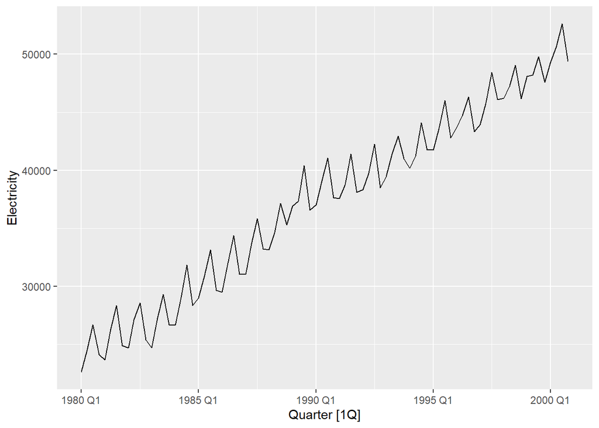

```r
aus_production %>%
  filter((year(Quarter) >= 1980 & year(Quarter)<= 2000)) %>%
  autoplot(Electricity)
```

Strong trend with a change in the slope of the trend around 1990.

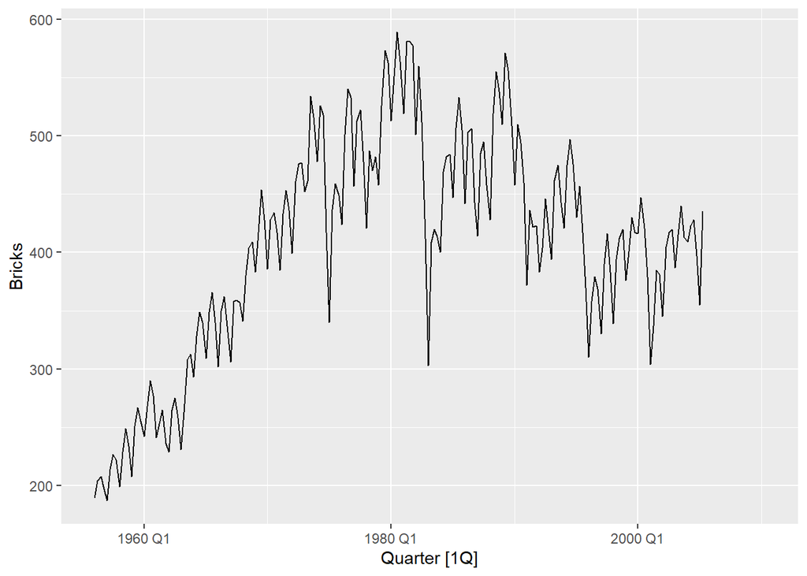

```r
autoplot(aus_production, Bricks)
```

Trended with recessions in 1983 and 1991

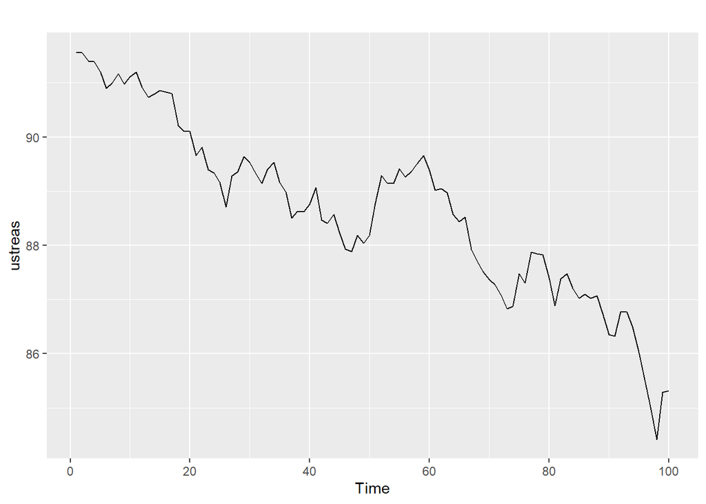

```r
autoplot(ustreas)
```

Looks like a downward trend, but it is part of a much longer cycle (not shown). You do not want to make forecasts with this data too long into the future.

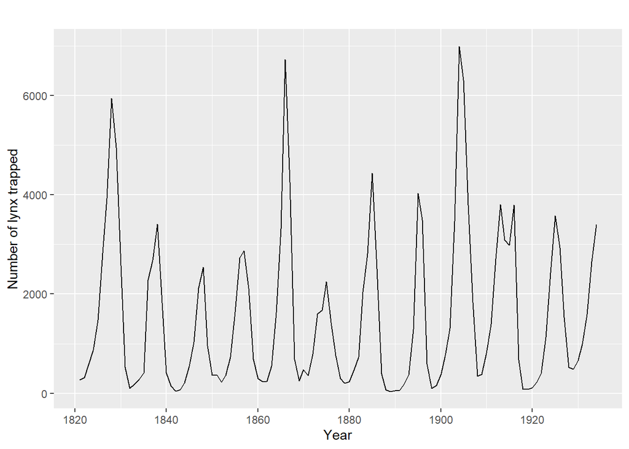

```r
autoplot(lynx) + xlab("Year") + ylab("Number of lynx trapped")
```

Number of lynx trapped anualy in the Hudson bay reach

- BECAUSE THIS IS ANUAL DATA, IT CANNOT BE SEASONAL
- Population of lynx raises when there is plenty of food
  - When food supply is low -> population plummets
  - SUrviving lynx have excess food -> population raises

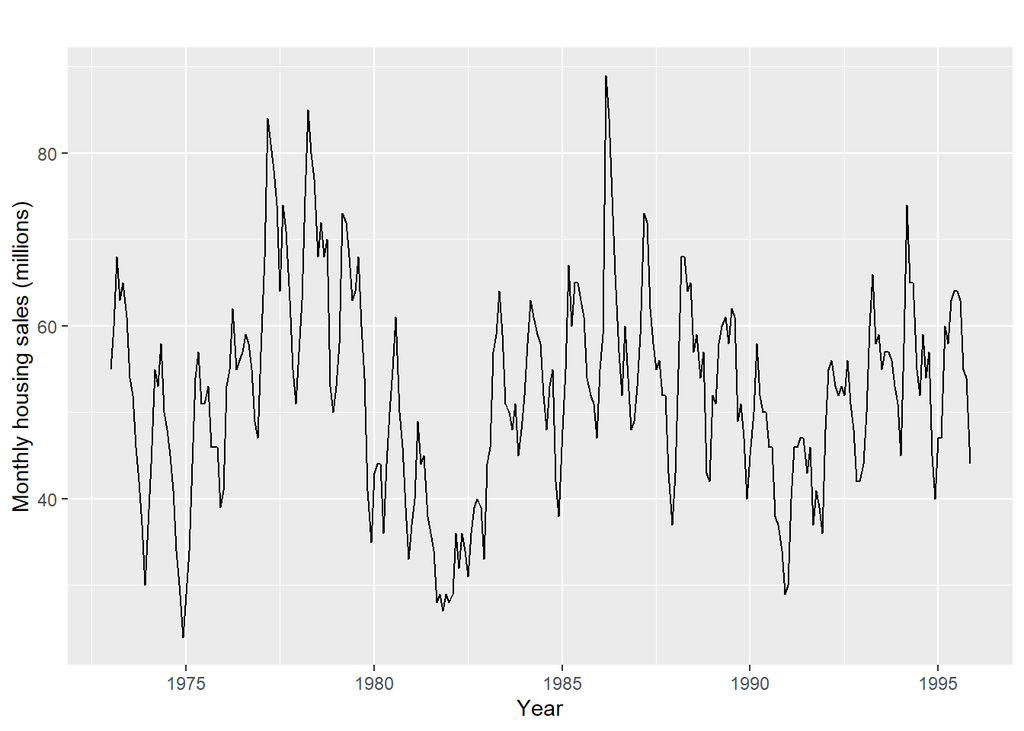

```r
autoplot(hsales) + xlab("Year") + ylab("Monthly housing sales (millions)")
```

Monthly sales of new family houses sold in the USA (1973-1995)

- Strong seasonality within each year
- Strong cyclic behaviour with period of 6-10 years

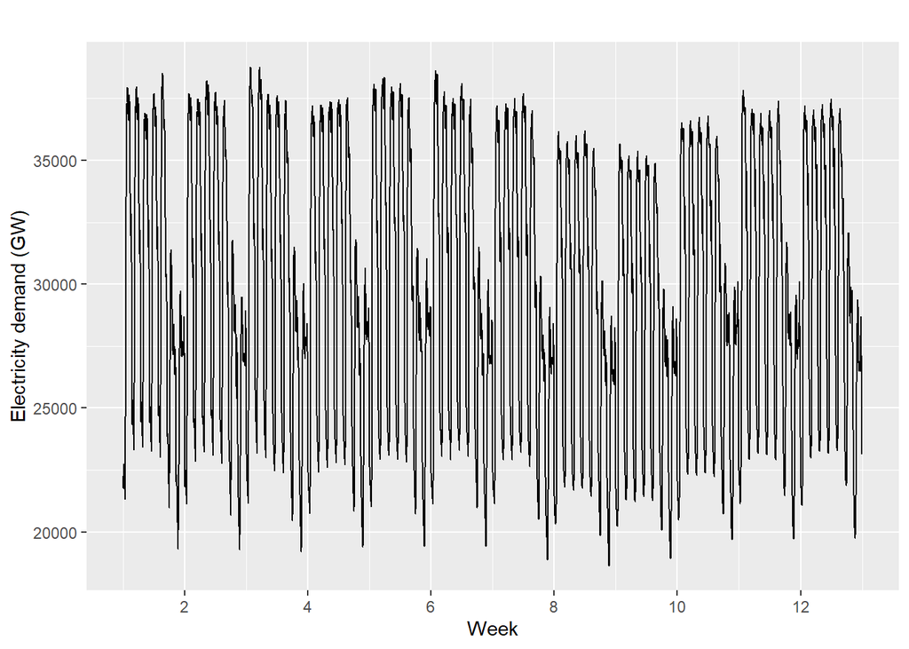

```r
autoplot(taylor) + xlab("Week") + ylab("Electricity demand (GW)")
```

Half hourly electricity demand in england and wales from Monday 5 June 2000 to Sunday 27 august 2000.

- Two types of seasonality
  - Daily pattern
  - Weekly pattern
- If we had data over a few years: we would see annual patern
- If we had data over a few decades: we might see a longer cyclic pattern # Time Plots

Already seen. Example for a10 creation.

```r
PBS %>%
  filter(ATC2 == "A10") %>%
  select(Month, Concession, Type, Cost) %>%
  summarise(TotalC = sum(Cost)) %>%

  # Comment on this assignment operator
  mutate(Cost = TotalC / 1e6) -> a10
```

```r
a10
```

```
## # A tsibble: 204 x 3 [1M]
##       Month  TotalC  Cost
##       <mth>   <dbl> <dbl>
##  1 1991 Jul 3526591  3.53
##  2 1991 Aug 3180891  3.18
##  3 1991 Sep 3252221  3.25
##  4 1991 Oct 3611003  3.61
##  5 1991 Nov 3565869  3.57
##  6 1991 Dec 4306371  4.31
##  7 1992 Jan 5088335  5.09
##  8 1992 Feb 2814520  2.81
##  9 1992 Mar 2985811  2.99
## 10 1992 Apr 3204780  3.20
## # ... with 194 more rows
```

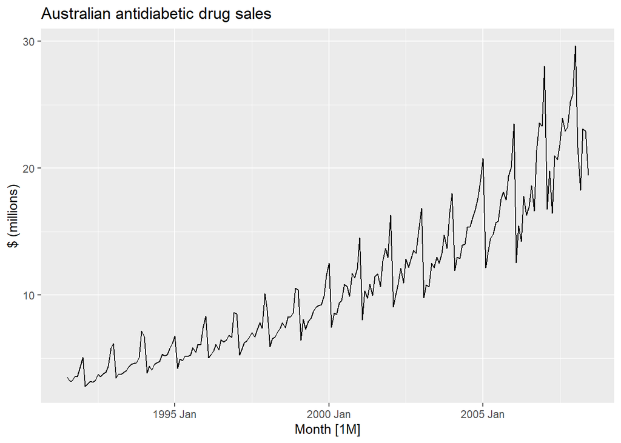

```r
autoplot(a10, Cost) +
  labs(y = "$ (millions)",
       title = "Australian antidiabetic drug sales")
```

# Seasonal Plots: gg_season

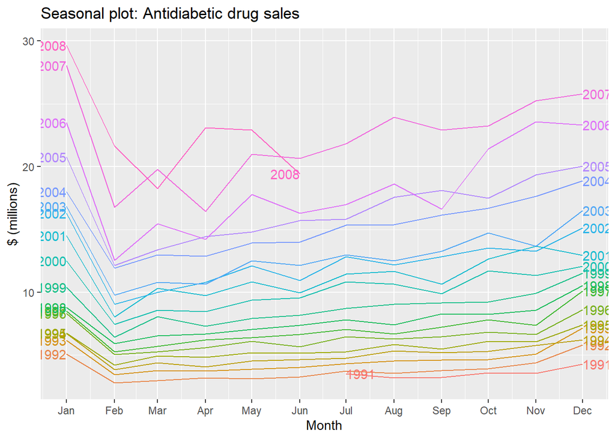

```r
a10 %>%
  gg_season(Cost, labels = "both") + # Labels -> "both", "right", "left"
  labs(y = "$ (millions)",
       title = "Seasonal plot: Antidiabetic drug sales")
```

- Seasonal pattern might be more clear
  - Large jump in sales each year.

## Example: hourly electricity demand

```r
head(vic_elec)
```

```
## # A tsibble: 6 x 5 [30m] <Australia/Melbourne>
##   Time                Demand Temperature Date       Holiday
##   <dttm>               <dbl>       <dbl> <date>     <lgl>
## 1 2012-01-01 00:00:00  4383.        21.4 2012-01-01 TRUE
## 2 2012-01-01 00:30:00  4263.        21.0 2012-01-01 TRUE
## 3 2012-01-01 01:00:00  4049.        20.7 2012-01-01 TRUE
## 4 2012-01-01 01:30:00  3878.        20.6 2012-01-01 TRUE
## 5 2012-01-01 02:00:00  4036.        20.4 2012-01-01 TRUE
## 6 2012-01-01 02:30:00  3866.        20.2 2012-01-01 TRUE
```

```r
tail(vic_elec)
```

```
## # A tsibble: 6 x 5 [30m] <Australia/Melbourne>
##   Time                Demand Temperature Date       Holiday
##   <dttm>               <dbl>       <dbl> <date>     <lgl>
## 1 2014-12-31 21:00:00  3928.        20.3 2014-12-31 FALSE
## 2 2014-12-31 21:30:00  3873.        19   2014-12-31 FALSE
## 3 2014-12-31 22:00:00  3792.        18.5 2014-12-31 FALSE
## 4 2014-12-31 22:30:00  3725.        17.7 2014-12-31 FALSE
## 5 2014-12-31 23:00:00  3762.        17.3 2014-12-31 FALSE
## 6 2014-12-31 23:30:00  3809.        17.1 2014-12-31 FALSE
```

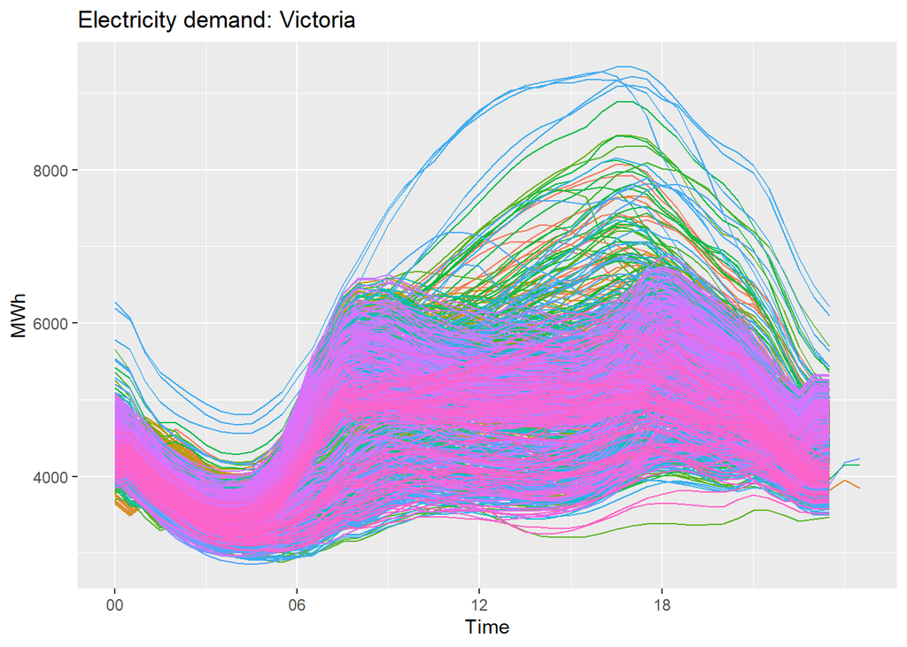

```r
vic_elec %>% gg_season(Demand, period = "day") +
  theme(legend.position = "none") +
  labs(y="MWh", title="Electricity demand: Victoria")
```

1. **Question:** what does each line represent in the data?
2. **Question:** how many dataponts do we have?
3. **Question:** how many lines do we have in our graph?
4. **Question** how many data points per line do we have?
5. Each line represents the demand in a specific day.
6. 365 * 24 * 2 * 3 = 52560
7. 365 * 3 = 1095
8. 52560 / 1095 = 48 (48 half hours in a day)

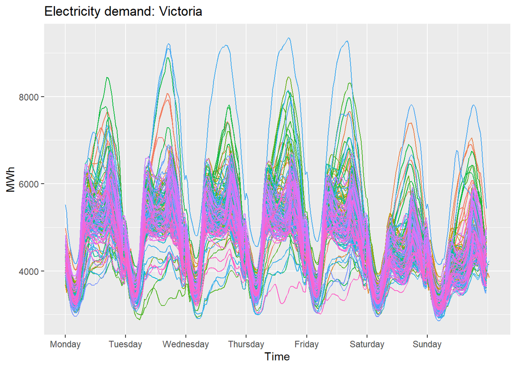

```r
vic_elec %>% gg_season(Demand, period = "week") +
  theme(legend.position = "none") +
  labs(y="MWh", title="Electricity demand: Victoria")
```

1. **Question:** what does each line represent in the data?
2. **Question:** how many weeks are there in a year?
3. **Question:** How many lines do we have in this data?
4. **Question** how many datapoints does each line have?
5. 52-53
6. 52 * 3
7. 7 * 24 * 2 = 336

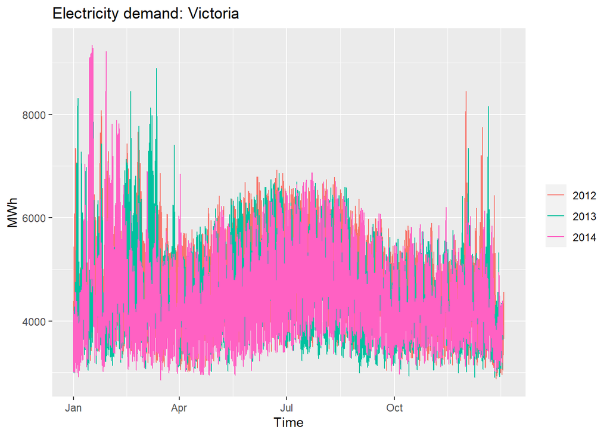

```r
vic_elec %>% gg_season(Demand, period = "year") +
  labs(y="MWh", title="Electricity demand: Victoria")
```

**Question:** what does each line represent?

**Question:** why is the data so dense?

Because we have many dataponts per line. Specifically:

365 * 24 * 2 = 17520

**Question:** propose an alternatve, less noisy way of representing the data:

For example: summarizing by month with a max, min and an average value.

## EXERCISE seasonal plots

The `aus_arrivals` (loaded with the `fpp3` library) data set comprises quarterly international arrivals (in thousands) to Australia from Japan, New Zealand, UK and the US. Use autoplot(), gg_season() and gg_subseries() to compare the differences between the arrivals from these four countries.

Create a:

- Timeplot of the arrivals using autoplot (one curve per country of origin)
- Seasonal plot using gg_eason (due to the structure of the data it will produce one graph per country of origin)

```r
aus_arrivals
```

```
## # A tsibble: 508 x 3 [1Q]
## # Key:       Origin [4]
##    Quarter Origin Arrivals
##      <qtr> <chr>     <int>
##  1 1981 Q1 Japan     14763
##  2 1981 Q2 Japan      9321
##  3 1981 Q3 Japan     10166
##  4 1981 Q4 Japan     19509
##  5 1982 Q1 Japan     17117
##  6 1982 Q2 Japan     10617
##  7 1982 Q3 Japan     11737
##  8 1982 Q4 Japan     20961
##  9 1983 Q1 Japan     20671
## 10 1983 Q2 Japan     12235
## # ... with 498 more rows
```

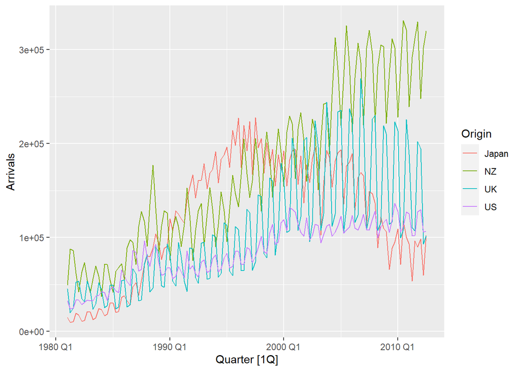

```r
aus_arrivals %>% autoplot(Arrivals)
```

Generally the number of arrivals to Australia is increasing over the entire series, with the exception of Japanese visitors which begin to decline after 1995. The series appear to have a seasonal pattern which varies proportionately to the number of arrivals. Interestingly, the number of visitors from NZ peaks sharply in 1988. The seasonal pattern from Japan appears to change substantially.

The seasonal pattern of arrivals appears to vary between each country. In particular, arrivals from the UK appears to be lowest in Q2 and Q3, and increase substantially for Q4 and Q1. Whereas for NZ visitors, the lowest period of arrivals is in Q1, and highest in Q3. Similar variations can be seen for Japan and US.

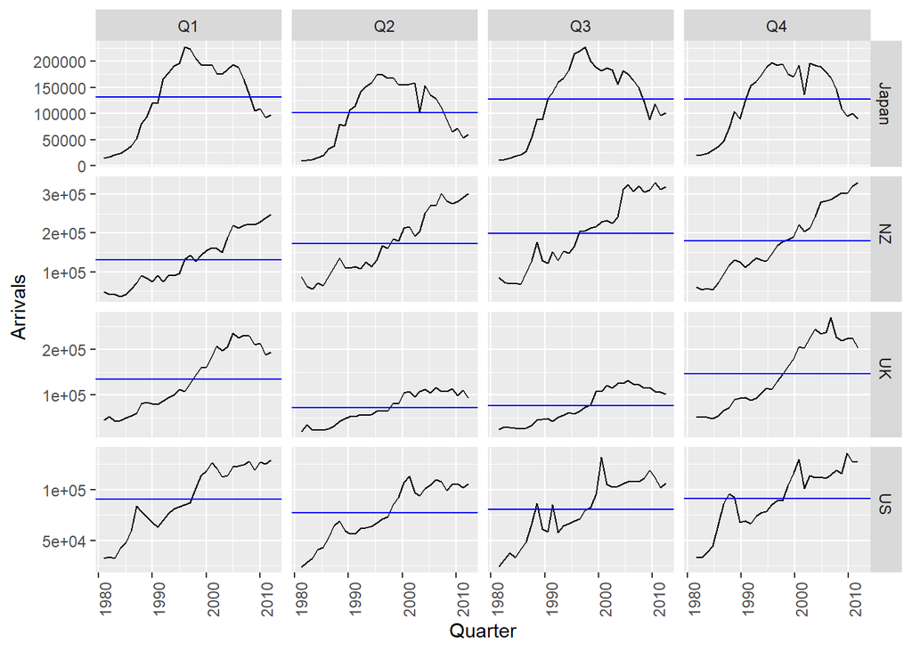

```r
aus_arrivals %>% gg_subseries(Arrivals)
```

Unusual observations:

- 2000 Q3: Spikes from the US (Sydney Olympics arrivals)
- 2001 Q3-Q4 are unusual for US (9/11 effect)
- 1991 Q3 is unusual for the US (Gulf war effect?)

# Seasonal subseries plots: gg_subseries

## Example with monthly data

```r
a10
```

```
## # A tsibble: 204 x 3 [1M]
##       Month  TotalC  Cost
##       <mth>   <dbl> <dbl>
##  1 1991 Jul 3526591  3.53
##  2 1991 Aug 3180891  3.18
##  3 1991 Sep 3252221  3.25
##  4 1991 Oct 3611003  3.61
##  5 1991 Nov 3565869  3.57
##  6 1991 Dec 4306371  4.31
##  7 1992 Jan 5088335  5.09
##  8 1992 Feb 2814520  2.81
##  9 1992 Mar 2985811  2.99
## 10 1992 Apr 3204780  3.20
## # ... with 194 more rows
```

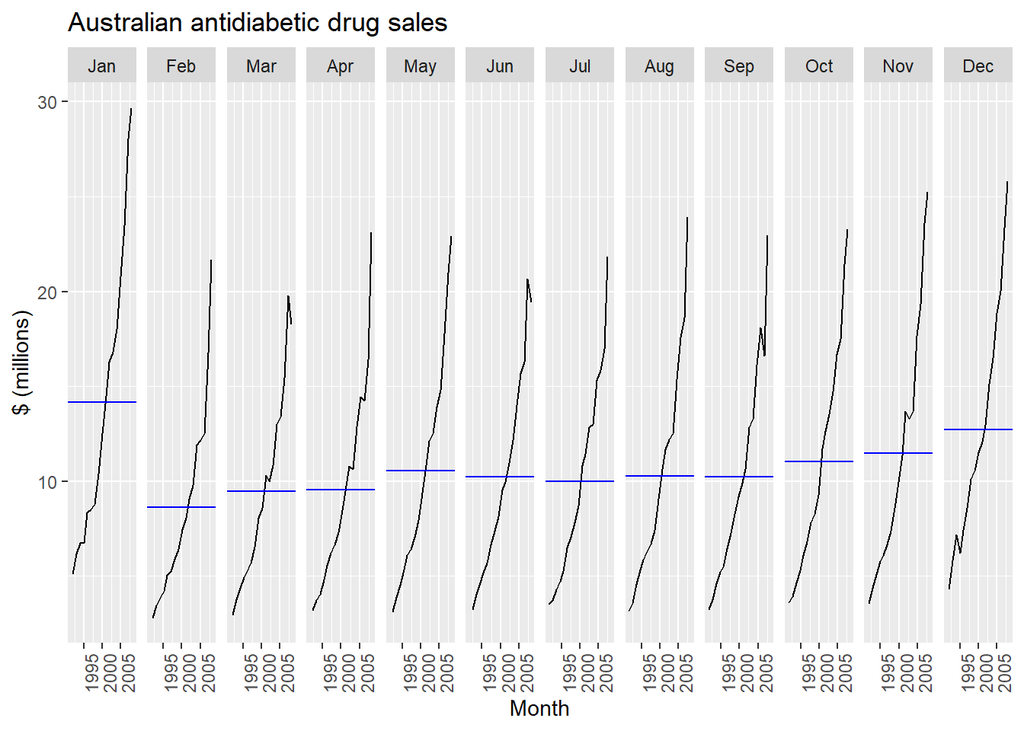

```r
a10 %>%
  gg_subseries(Cost) +
  labs(
    y = "$ (millions)",
    title = "Australian antidiabetic drug sales",
  )
```

Why does it produce this output?

Because of the date format: Year-Month.

- The **greatest time unit** is taken as **period**. In this case **year**
- The **smallest time unit** is taken as **unit in which the period is to be split.** In this case **month**

As you can see, **specifying “year” as the period is simply redundant.**

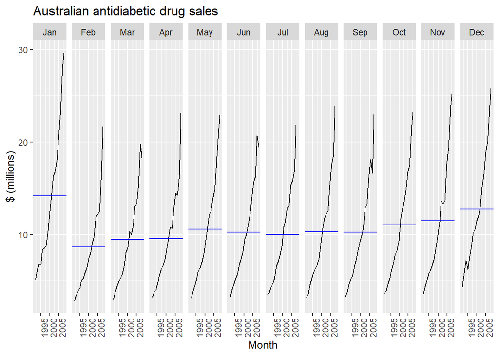

```r
a10 %>%
  gg_subseries(Cost, period = "year") +
  labs(
    y = "$ (millions)",
    title = "Australian antidiabetic drug sales",
  )
```

**Question**: what will this output provide?

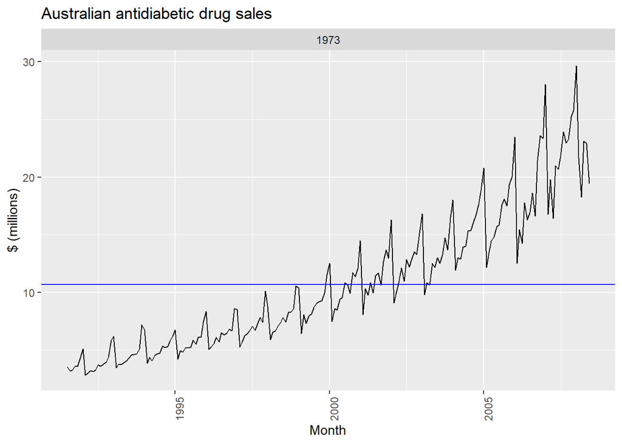

```r
a10 %>%
  gg_subseries(Cost, period = "month") +
  labs(
    y = "$ (millions)",
    title = "Australian antidiabetic drug sales",
  )
```

It essentially provides the same output as a time plot because we are specifying the smallest time unit in the index (month) as period. The period can therefore not be further split.

**Question** what is the output of this code?

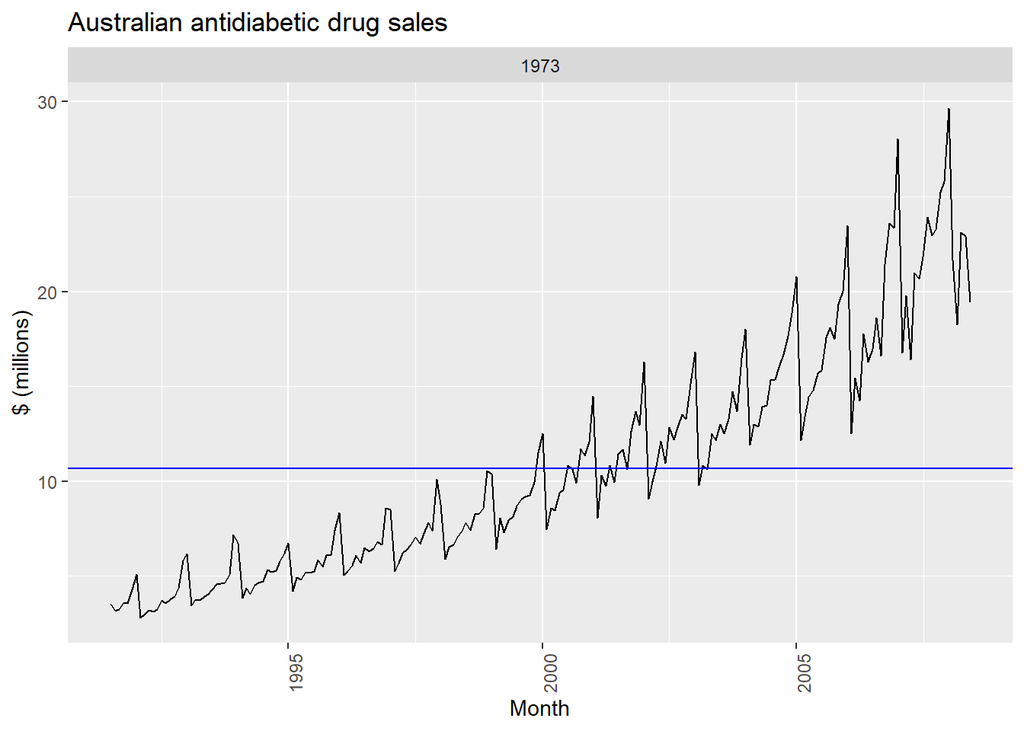

```r
a10 %>%
  gg_subseries(Cost, period = "day") +
  labs(
    y = "$ (millions)",
    title = "Australian antidiabetic drug sales",
  )
```

Same output as before. The smallest time unit in the index is “month”, which is greter than “day”. Therefore it is pointless to specify day as the period.

## Example with sub-daily data

NOTE: this example is not extremely important from a mathematical point of view, but rather to be able to understand the logic behind sub-seasonal plots.

```r
head(vic_elec)
```

```
## # A tsibble: 6 x 5 [30m] <Australia/Melbourne>
##   Time                Demand Temperature Date       Holiday
##   <dttm>               <dbl>       <dbl> <date>     <lgl>
## 1 2012-01-01 00:00:00  4383.        21.4 2012-01-01 TRUE
## 2 2012-01-01 00:30:00  4263.        21.0 2012-01-01 TRUE
## 3 2012-01-01 01:00:00  4049.        20.7 2012-01-01 TRUE
## 4 2012-01-01 01:30:00  3878.        20.6 2012-01-01 TRUE
## 5 2012-01-01 02:00:00  4036.        20.4 2012-01-01 TRUE
## 6 2012-01-01 02:30:00  3866.        20.2 2012-01-01 TRUE
```

```r
tail(vic_elec)
```

```
## # A tsibble: 6 x 5 [30m] <Australia/Melbourne>
##   Time                Demand Temperature Date       Holiday
##   <dttm>               <dbl>       <dbl> <date>     <lgl>
## 1 2014-12-31 21:00:00  3928.        20.3 2014-12-31 FALSE
## 2 2014-12-31 21:30:00  3873.        19   2014-12-31 FALSE
## 3 2014-12-31 22:00:00  3792.        18.5 2014-12-31 FALSE
## 4 2014-12-31 22:30:00  3725.        17.7 2014-12-31 FALSE
## 5 2014-12-31 23:00:00  3762.        17.3 2014-12-31 FALSE
## 6 2014-12-31 23:30:00  3809.        17.1 2014-12-31 FALSE
```

**Question**: what would be the output of this code? **DO NOT RUN THIS CELL. It might crash your computer.**

```r
vic_elec %>%
  gg_subseries(Demand) +
  labs(
    y = "Demand [MW]",
    title = "Half-hourly energy demand in the state of Victoria",
  )
```

It would take **the greatest time unit in the index** (year) and split it by the **smallest time unit in the index** (half-an hour). **Since there are 365 * 24 * 2 = 17520 half-hours in a year, it would create 17520 graphs.** This would be useless, unreadable and would probably crash your computer.

**Takeaway**: we need to be careful when we want to use the gg_subseries function with hourly data.

A first possibility would be to specify **period = “daily”**. This is a first option if we have sub-daily data because a day is the **immediately superior time unit** if we are dealing with hourly data.

**Question**: what is the output of this code?

```r
vic_elec %>%
  gg_subseries(Demand, period = "day") +
  labs(
    y = "[MW]",
    title = "Total electricity demand for Victoria, Australia"
  )

# Necessary to explore the output fiven the density of the data
ggsave("subseasonal_demand_hourly_PeriodDay.svg", width = 30, height = 5)
```

48 graphs. The period = “day” divided by the smallest time unit (30 mins)

See the output in separate file *subseasonal_demand_hourly_PeriodDay.svg*

Another option is to create an aggregation by month:

```r
vic_elec_m <- vic_elec %>%
  index_by(month = yearmonth(Time)) %>%
  summarise(
    avg_demand = mean(Demand)
  )

vic_elec_m
```

```
## # A tsibble: 36 x 2 [1M]
##       month avg_demand
##       <mth>      <dbl>
##  1 2012 Jan      4866.
##  2 2012 Feb      4939.
##  3 2012 Mar      4534.
##  4 2012 Apr      4439.
##  5 2012 May      4956.
##  6 2012 Jun      5131.
##  7 2012 Jul      5086.
##  8 2012 Aug      5035.
##  9 2012 Sep      4561.
## 10 2012 Oct      4496.
## # ... with 26 more rows
```

**Question**: what is the output of this code?

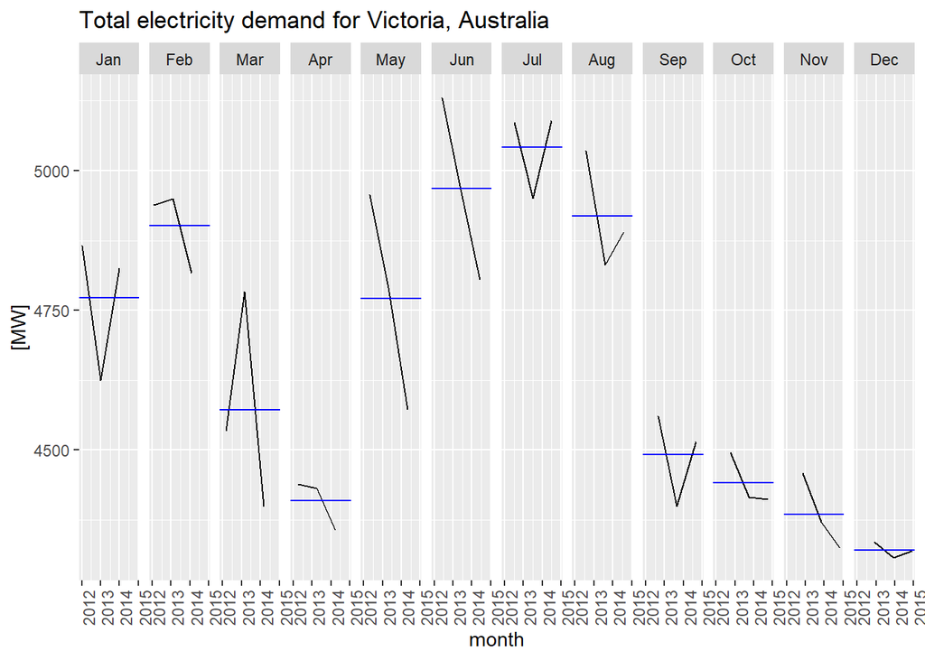

```r
vic_elec_m %>%
  gg_subseries(avg_demand, period = "year") +
  labs(
    y = "[MW]",
    title = "Total electricity demand for Victoria, Australia"
  )
```

**Answer**: 12 graphs (the period = “year” divided in the smallest time unit (month))

We could also aggregate by quarter

```r
vic_elec_q <- vic_elec %>%
  index_by(quarter = yearquarter(Time)) %>%
  summarise(
    avg_demand = mean(Demand)
  )

vic_elec_q
```

```
## # A tsibble: 12 x 2 [1Q]
##    quarter avg_demand
##      <qtr>      <dbl>
##  1 2012 Q1      4776.
##  2 2012 Q2      4843.
##  3 2012 Q3      4898.
##  4 2012 Q4      4430.
##  5 2013 Q1      4780.
##  6 2013 Q2      4728.
##  7 2013 Q3      4731.
##  8 2013 Q4      4364.
##  9 2014 Q1      4676.
## 10 2014 Q2      4577.
## 11 2014 Q3      4835.
## 12 2014 Q4      4352.
```

**Question**: what is the output of this code?

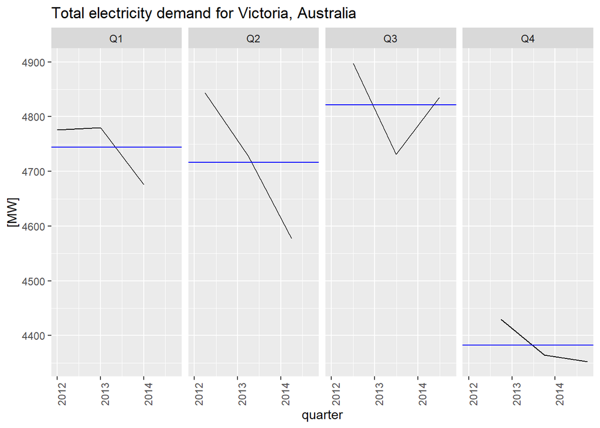

```r
vic_elec_q %>%
  gg_subseries(avg_demand, period = "year") +
  labs(
    y = "[MW]",
    title = "Total electricity demand for Victoria, Australia"
  )
```

**Answer**: 4 graphs (period = “year” subdivided in the smallest unit)

## Exercise

1. Aggregate the vic_elec data into daily data computing the average demand for each day using `index_by()` + `summarise()` combined with `mean()`
2. Create a gg_subseries plot that has one graph for each day of the month and plots the values on each day for each month **only for the year 2012**

**See expected output on the separate file** *subseasonal_demand_daily_PeriodMonth.svg*

```r
vic_elec_d <- vic_elec %>%

  # STEP 1: aggregate by date:
  index_by(day = as_date(Time)) %>%

  # STEP 2: obtain average values
  summarise(
    avg_demand = mean(Demand)
  )

# STEP 3: Inspect result
vic_elec_d
```

```
## # A tsibble: 1,096 x 2 [1D]
##    day        avg_demand
##    <date>          <dbl>
##  1 2012-01-01      4634.
##  2 2012-01-02      5374.
##  3 2012-01-03      5565.
##  4 2012-01-04      4640.
##  5 2012-01-05      4387.
##  6 2012-01-06      4380.
##  7 2012-01-07      4219.
##  8 2012-01-08      4029.
##  9 2012-01-09      4454.
## 10 2012-01-10      4480.
## # ... with 1,086 more rows
```

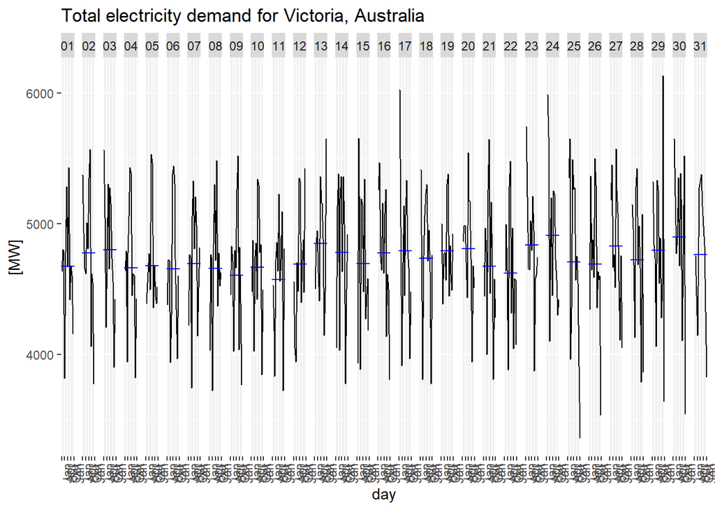

```r
# Filter values for 2012
filter(vic_elec_d, year(day) == 2012) %>%

  # Generate
  gg_subseries(avg_demand, period = "month") +
  labs(
    y = "[MW]",
    title = "Total electricity demand for Victoria, Australia"
  )
```

```r
ggsave("subseasonal_demand_daily_PeriodMonth.svg", width = 40, height = 5)
```

## Example with sub-daily data

**Question**: what would be the output of this code?

```r
# Filter values for 2012
filter(vic_elec_d, year(day) == 2012) %>%

  # Create gg subseries plot
  gg_subseries(avg_demand, period = "year") +
  labs(
    y = "[MW]",
    title = "Total electricity demand for Victoria, Australia"
  )

ggsave("subseasonal_demand_daily_PeriodYear.svg", width = 40, height = 5)
```

See output in separate file *subseasonal_demand_daily_PeriodYear.svg*

# Scatter plots

## Two variables

```r
vic_elec
```

```
## # A tsibble: 52,608 x 5 [30m] <Australia/Melbourne>
##    Time                Demand Temperature Date       Holiday
##    <dttm>               <dbl>       <dbl> <date>     <lgl>
##  1 2012-01-01 00:00:00  4383.        21.4 2012-01-01 TRUE
##  2 2012-01-01 00:30:00  4263.        21.0 2012-01-01 TRUE
##  3 2012-01-01 01:00:00  4049.        20.7 2012-01-01 TRUE
##  4 2012-01-01 01:30:00  3878.        20.6 2012-01-01 TRUE
##  5 2012-01-01 02:00:00  4036.        20.4 2012-01-01 TRUE
##  6 2012-01-01 02:30:00  3866.        20.2 2012-01-01 TRUE
##  7 2012-01-01 03:00:00  3694.        20.1 2012-01-01 TRUE
##  8 2012-01-01 03:30:00  3562.        19.6 2012-01-01 TRUE
##  9 2012-01-01 04:00:00  3433.        19.1 2012-01-01 TRUE
## 10 2012-01-01 04:30:00  3359.        19.0 2012-01-01 TRUE
## # ... with 52,598 more rows
```

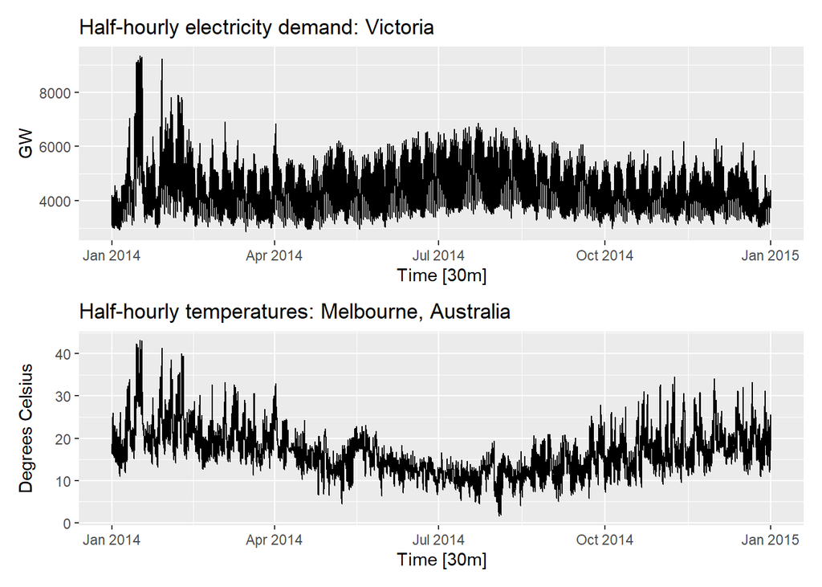

```r
p1 <- vic_elec %>%
  filter(year(Time) == 2014) %>%
  autoplot(Demand) +
  labs(y = "GW",
       title = "Half-hourly electricity demand: Victoria")

p2 <- vic_elec %>%
  filter(year(Time) == 2014) %>%
  autoplot(Temperature) +
  labs(
    y = "Degrees Celsius",
    title = "Half-hourly temperatures: Melbourne, Australia"
  )

p1 / p2
```

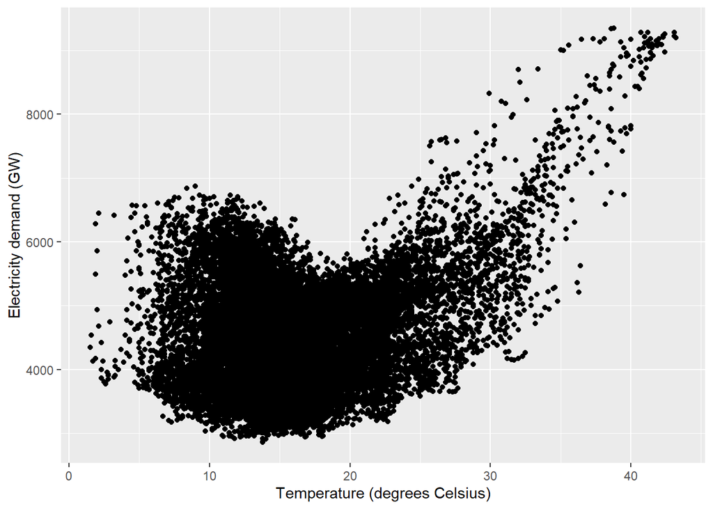

```r
vic_elec %>%
  filter(year(Time) == 2014) %>%
  ggplot(aes(x = Temperature, y = Demand)) +
  geom_point() +
  labs(x = "Temperature (degrees Celsius)",
       y = "Electricity demand (GW)")
```

## Several variables - scatterplot matrix

```r
visitors <- tourism %>%
  group_by(State) %>%
  summarise(Trips = sum(Trips))

visitors
```

```
## # A tsibble: 640 x 3 [1Q]
## # Key:       State [8]
##    State Quarter Trips
##    <chr>   <qtr> <dbl>
##  1 ACT   1998 Q1  551.
##  2 ACT   1998 Q2  416.
##  3 ACT   1998 Q3  436.
##  4 ACT   1998 Q4  450.
##  5 ACT   1999 Q1  379.
##  6 ACT   1999 Q2  558.
##  7 ACT   1999 Q3  449.
##  8 ACT   1999 Q4  595.
##  9 ACT   2000 Q1  600.
## 10 ACT   2000 Q2  557.
## # ... with 630 more rows
```

```r
# Check distinct values of column "State"
distinct(visitors, State)
```

```
## # A tibble: 8 x 1
##   State
##   <chr>
## 1 ACT
## 2 New South Wales
## 3 Northern Territory
## 4 Queensland
## 5 South Australia
## 6 Tasmania
## 7 Victoria
## 8 Western Australia
```

```r
visitors %>%
  pivot_wider(values_from=Trips, names_from=State)
```

```
## # A tsibble: 80 x 9 [1Q]
##    Quarter   ACT `New South Wales` `Northern Territ~ Queensland `South Australi~
##      <qtr> <dbl>             <dbl>             <dbl>      <dbl>            <dbl>
##  1 1998 Q1  551.             8040.              181.      4041.            1735.
##  2 1998 Q2  416.             7166.              314.      3968.            1395.
##  3 1998 Q3  436.             6748.              528.      4594.            1213.
##  4 1998 Q4  450.             7282.              248.      4203.            1453.
##  5 1999 Q1  379.             7585.              185.      4332.            1541.
##  6 1999 Q2  558.             7054.              366.      4824.            1636.
##  7 1999 Q3  449.             6724.              501.      5018.            1283.
##  8 1999 Q4  595.             7136.              248.      4350.            1387.
##  9 2000 Q1  600.             7296.              206.      4413.            1833.
## 10 2000 Q2  557.             6445.              360.      4344.            1415.
## # ... with 70 more rows, and 3 more variables: Tasmania <dbl>, Victoria <dbl>,
## #   Western Australia <dbl>
```

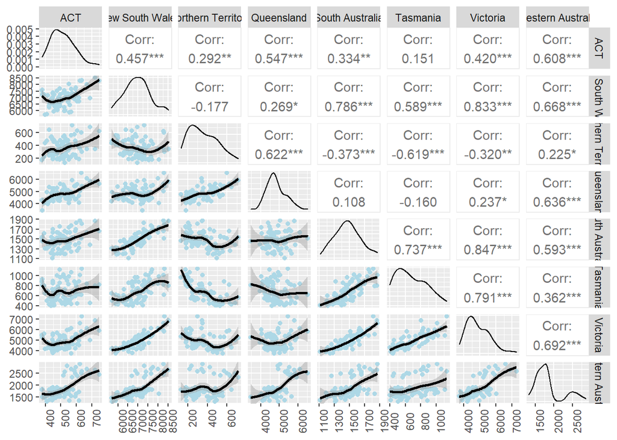

```r
visitors %>%
  pivot_wider(values_from=Trips, names_from=State) %>%
  GGally::ggpairs(columns = 2:9, lower = list(continuous = wrap("smooth_loess", color="lightblue"))) + theme(axis.text.x = element_text(angle = 90))
```

# Lag plots

```r
recent_production <- aus_production %>%
  filter(year(Quarter) >= 2000)

recent_production
```

```
## # A tsibble: 42 x 7 [1Q]
##    Quarter  Beer Tobacco Bricks Cement Electricity   Gas
##      <qtr> <dbl>   <dbl>  <dbl>  <dbl>       <dbl> <dbl>
##  1 2000 Q1   421    5169    416   1835       49320   164
##  2 2000 Q2   402    4860    447   2070       50670   199
##  3 2000 Q3   414    5185    421   1898       52623   213
##  4 2000 Q4   500    4763    379   1652       49350   173
##  5 2001 Q1   451    4217    304   1554       51658   177
##  6 2001 Q2   380    4959    337   1717       51103   205
##  7 2001 Q3   416    5196    385   1679       52226   218
##  8 2001 Q4   492    4522    381   1836       50778   185
##  9 2002 Q1   428    3843    345   1729       50639   166
## 10 2002 Q2   408    4806    405   1992       51486   204
## # ... with 32 more rows
```

Let us know plot the time plot of our data to have a first impression of the series, followed by the lagged plot.

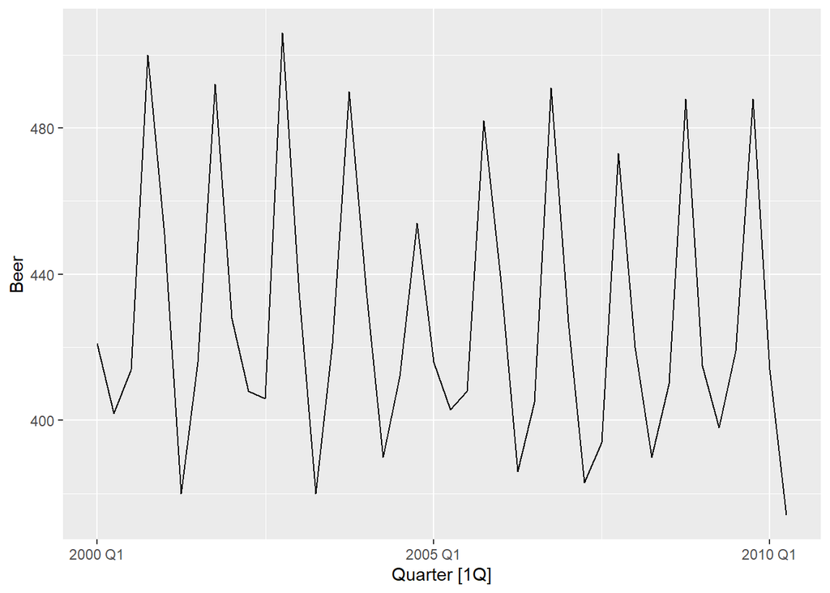

```r
recent_production %>% autoplot(Beer)
```

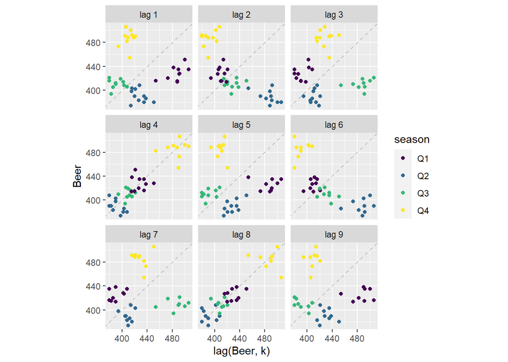

```r
recent_production %>%
  gg_lag(y = Beer, geom = "point", arrow=TRUE) +
  labs(x = "lag(Beer, k)")
```

**Question**: can anybody explain this graph?

## Lagged variables: `lag()`

To understand the lag plot, we need to understand what a lagged variable is and how to build them ourselves. We will do this using the `lag()` function. Lets create the first 9 lags:

```r
for (i in seq(1, 9)) {
  lag_name = paste0("Beer_lag", as.character(i))
  recent_production[[lag_name]] = lag(recent_production[["Beer"]], i)
}

recent_production$Qnumber <- paste0("Q",quarter(recent_production$Quarter))

select(recent_production, Quarter, Qnumber, Beer, Beer_lag1:Beer_lag9)
```

```
## # A tsibble: 42 x 12 [1Q]
##    Quarter Qnumber  Beer Beer_lag1 Beer_lag2 Beer_lag3 Beer_lag4 Beer_lag5
##      <qtr> <chr>   <dbl>     <dbl>     <dbl>     <dbl>     <dbl>     <dbl>
##  1 2000 Q1 Q1        421        NA        NA        NA        NA        NA
##  2 2000 Q2 Q2        402       421        NA        NA        NA        NA
##  3 2000 Q3 Q3        414       402       421        NA        NA        NA
##  4 2000 Q4 Q4        500       414       402       421        NA        NA
##  5 2001 Q1 Q1        451       500       414       402       421        NA
##  6 2001 Q2 Q2        380       451       500       414       402       421
##  7 2001 Q3 Q3        416       380       451       500       414       402
##  8 2001 Q4 Q4        492       416       380       451       500       414
##  9 2002 Q1 Q1        428       492       416       380       451       500
## 10 2002 Q2 Q2        408       428       492       416       380       451
## # ... with 32 more rows, and 4 more variables: Beer_lag6 <dbl>,
## #   Beer_lag7 <dbl>, Beer_lag8 <dbl>, Beer_lag9 <dbl>
```

We have added one column for each of the first 9 lagged variables, as well as a column to identify to which quarter an observation belongs (this will be helpful to assign colors to the scatter plots that will follow).

As you can see, first lag of the variable consists plain and simply in shifting the time series by 1 spot. Lag 2 by two spots… and so on.

Using these lagged variables, let us know create each of the panes that make up the output of gg_lag. That is: the scatter plot of the variable (Beer) against its lag (e.g. Beer_lag1).

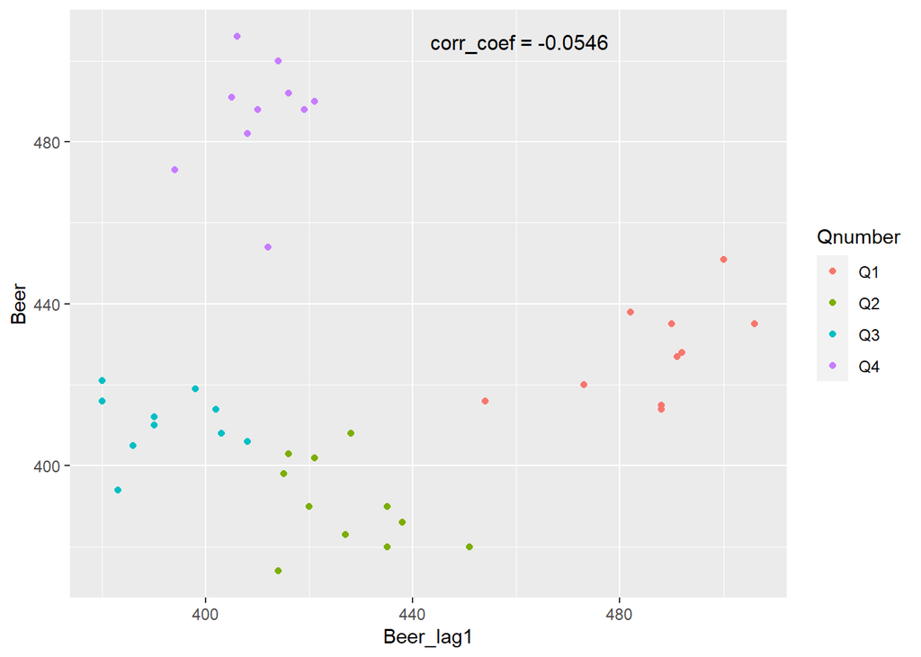

```r
# Parameter: change this number to show the scatter plot of the variable against a different lag
lag_nr = "1"

lag_name = paste0("Beer_lag", lag_nr)

pearson <- round(cor(recent_production$Beer, recent_production[[lag_name]], use="na.or.complete"), 4)

ggplot(data = recent_production) +

  # Create the scatter plot
  geom_point(mapping = aes(x = .data[[lag_name]], y = Beer, color = Qnumber)) +

  # Print an annotation on the graph with the pearson's correlation coefficient.
  annotate(
    geom = "text", x = Inf, y = Inf,
    label = paste("corr_coef =", as.character(pearson)), hjust = 2, vjust = 2.5, size = 4
  )
```

Essentially the lag plot is a set scatter plots of the original variable (Beer) against its different lags.

**They let us know to which extent a variable correlates to its past values**. Remember that **past observations tend to influence future values**, which introduces a correlation between values of the time series (the iid hypothesis does not apply in time series).

# Autocorrelation

## Autocorrelation coefficients

Now we would like to summarize each of the scatterplots in the lag plot with a statistic and produce a single graph that would give us an overview of the strength of the dependency between a series and its past values. A correlation coefficient seems like a very good candidate, since it measures the strength of the linear relationship between two variables.

This is exactly the purpose of the autocorrelation function. Let us compare the pearson’s correlation coefficient between x and y and the definition of the autocorrelation coefficient with the k-th lag:

k-th autocorrelation coefficient:

$$rk = \frac{\sum_{t=k+1}^{T} (y_t - \bar{y})(y_{t-k}-\bar{y})}{\sum_{t=1}^{T} (y_t - \bar{y})^2}$$

where:

- $T$ is the length of the complete time series.
- $k$ is the number of the specific lag for which we want the autocorrelation coefficient.

REMINDER: Pearsons correlation coefficient:

$$r = \frac{\sum(x_i - \bar{x})(y_{i}-\bar{y})}{\sqrt{\sum(x_i - \bar{x})^2(y_i - \bar{y})^2}}$$

**NOTE:** due to the shifting process, the autocorrelation coefficients do not exactly match the perason’s correlation coeffiients. More about this later in this notebook.

### Correlogram

The correlogram is a depiction fo the autocorrelation coefficients of the time series for different lags.

The autocorrelation coefficients can be computed using the function `ACF()` of the ‘feasts’ package (loaded under the hood when `fpp3` was loaded).

```r
ACFs <- round(recent_production %>% ACF(Beer), 3)
ACFs
```

```
## # A tsibble: 16 x 2 [1Q]
##      lag    acf
##    <lag>  <dbl>
##  1    1Q -0.053
##  2    2Q -0.758
##  3    3Q -0.026
##  4    4Q  0.802
##  5    5Q -0.077
##  6    6Q -0.657
##  7    7Q  0.001
##  8    8Q  0.707
##  9    9Q -0.089
## 10   10Q -0.588
## 11   11Q  0.024
## 12   12Q  0.632
## 13   13Q -0.066
## 14   14Q -0.505
## 15   15Q -0.009
## 16   16Q  0.498
```

The output is the autocorrelation coefficient for each of the lags (Q has been added to the lag labels because each time step is equivalent to one quarter).

Now let us create the correlogram. This can be easily done using autoplot, which recognises the output of the ACF() function as an object that needs to be dealt with differently:

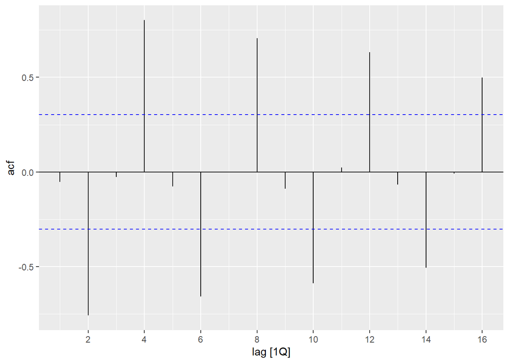

```r
autoplot(ACFs)
```

The correlogram is nothing but a depiction of the value of the k-th autocorrelation coefficient at the location of the k-th lag. You can match each of the values in the correlogram to the output of the ACF function shown before.

- **Example**: at lag 4, the value of the ACF is 0.802. The bar in the correlogram has this length. This means that there is a strong positive correlation between the value of the series at time $t$ and the value of the series at time $t_{-4}$.

## Trend in ACF plots

- Autocorrelations for small lags tend to be large and positive (near observations are near in value).
  - Positive ACF with values that slowly decrease as lags increase

## Seasonal data and ACF plots

- Autocorrelations will be larger for seasonal lags (at multiples of the seasonal period)

## Example

```
## Plot variable not specified, automatically selected `.vars = TotalC`
```

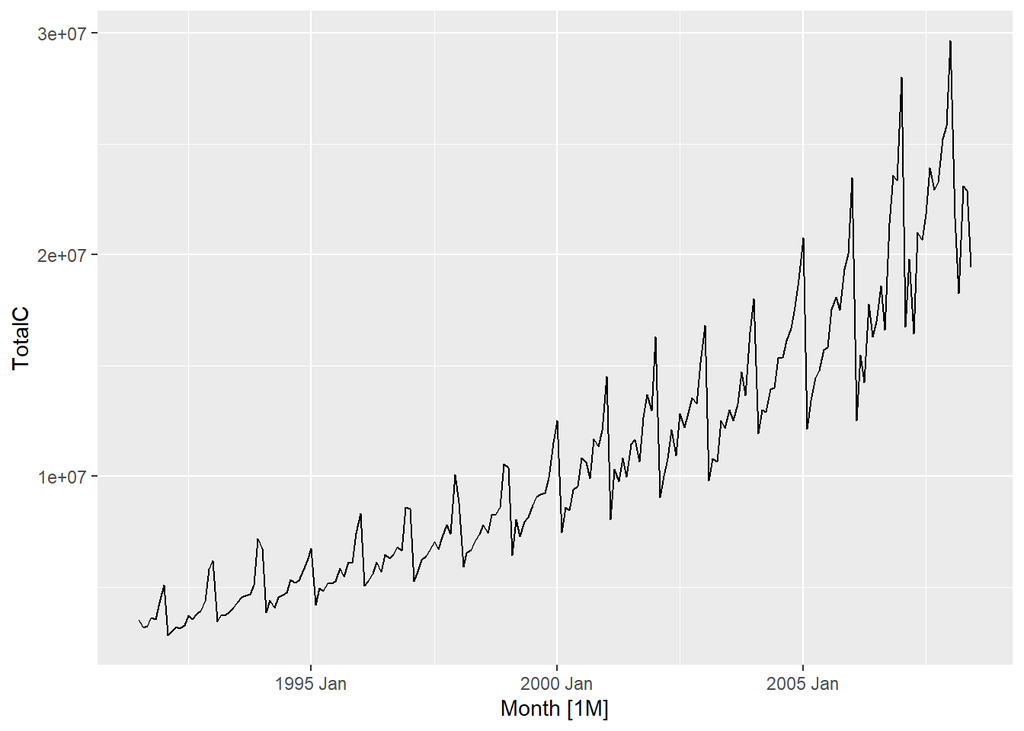

```r
autoplot(a10)
```

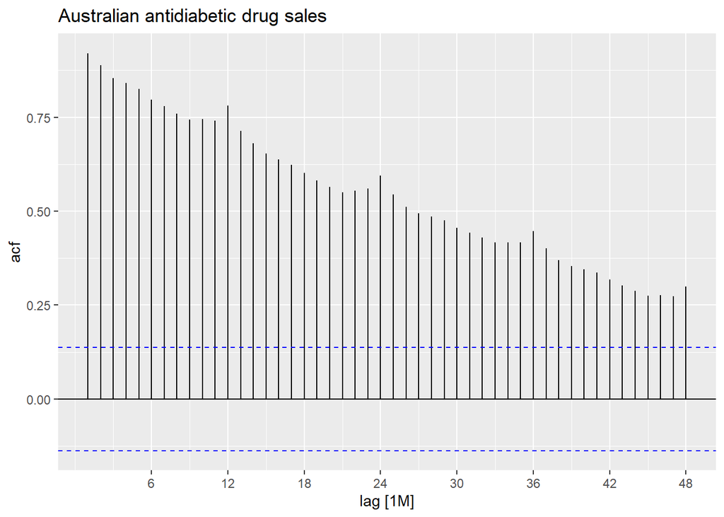

```r
a10 %>%
  ACF(Cost, lag_max = 48) %>%
  autoplot() +
  labs(title="Australian antidiabetic drug sales")
```

In the graph above, the trend component, the slow decrease in the ACF as the lags increase is due to the trend component. The “scallped” shape (the spikes at lags 12, 24, 36…) is due to the seasonality.

## Exercise

Use the following graphics functions: `autoplot()`, `gg_season()`, `gg_subseries()`, `gg_lag()`, `ACF()` and explore features of the time series `Total Private` from the dataset `us_employment` (loaded with `fpp3`):

```r
us_employment
```

```
## # A tsibble: 143,412 x 4 [1M]
## # Key:       Series_ID [148]
##       Month Series_ID     Title         Employed
##       <mth> <chr>         <chr>            <dbl>
##  1 1939 Jan CEU0500000001 Total Private    25338
##  2 1939 Feb CEU0500000001 Total Private    25447
##  3 1939 Mar CEU0500000001 Total Private    25833
##  4 1939 Apr CEU0500000001 Total Private    25801
##  5 1939 May CEU0500000001 Total Private    26113
##  6 1939 Jun CEU0500000001 Total Private    26485
##  7 1939 Jul CEU0500000001 Total Private    26481
##  8 1939 Aug CEU0500000001 Total Private    26848
##  9 1939 Sep CEU0500000001 Total Private    27468
## 10 1939 Oct CEU0500000001 Total Private    27830
## # ... with 143,402 more rows
```

```r
total_private <- us_employment %>%
  filter(Title == "Total Private")

total_private
```

```
## # A tsibble: 969 x 4 [1M]
## # Key:       Series_ID [1]
##       Month Series_ID     Title         Employed
##       <mth> <chr>         <chr>            <dbl>
##  1 1939 Jan CEU0500000001 Total Private    25338
##  2 1939 Feb CEU0500000001 Total Private    25447
##  3 1939 Mar CEU0500000001 Total Private    25833
##  4 1939 Apr CEU0500000001 Total Private    25801
##  5 1939 May CEU0500000001 Total Private    26113
##  6 1939 Jun CEU0500000001 Total Private    26485
##  7 1939 Jul CEU0500000001 Total Private    26481
##  8 1939 Aug CEU0500000001 Total Private    26848
##  9 1939 Sep CEU0500000001 Total Private    27468
## 10 1939 Oct CEU0500000001 Total Private    27830
## # ... with 959 more rows
```

```
## Plot variable not specified, automatically selected `.vars = Employed`
```

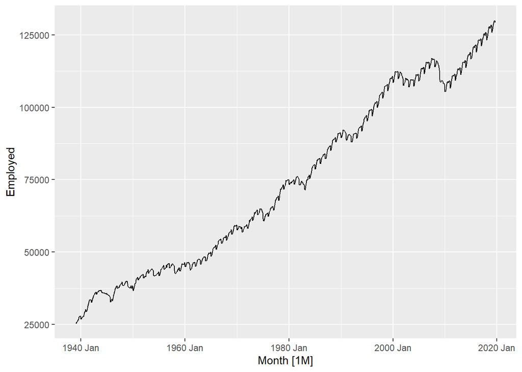

```r
autoplot(total_private)
```

There is a strong trend and seasonality. Some cyclic behaviour is seen, with a big drop due to the global financial crisis.

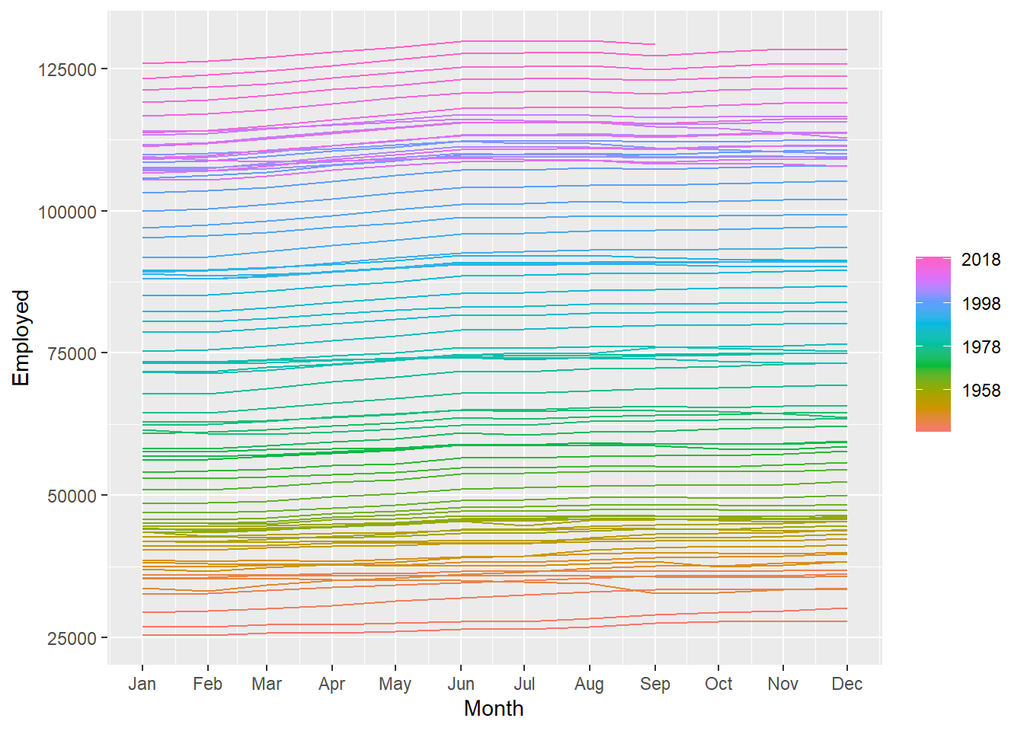

```r
total_private %>% gg_season(Employed)
```

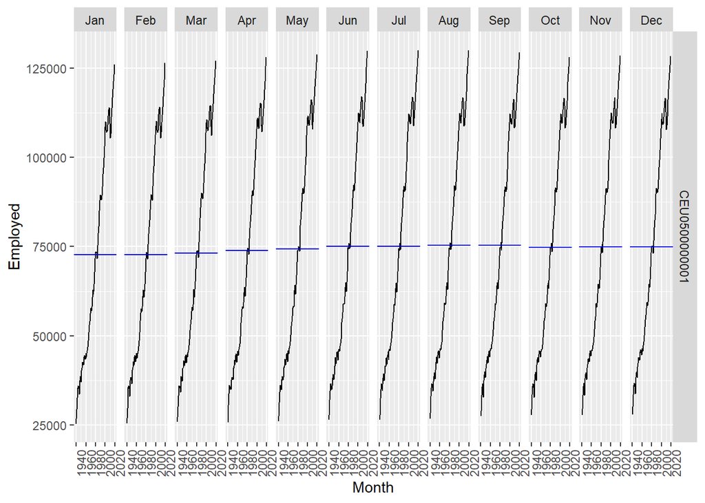

```r
gg_subseries(total_private, Employed)
```

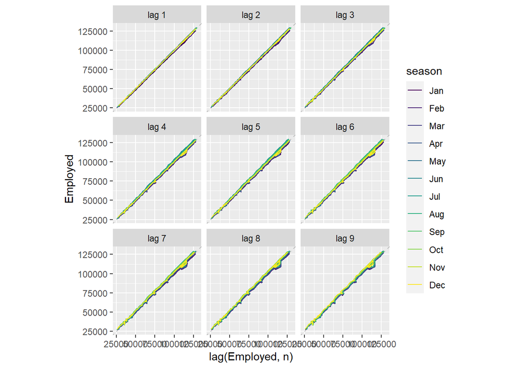

```r
gg_lag(total_private, Employed)
```

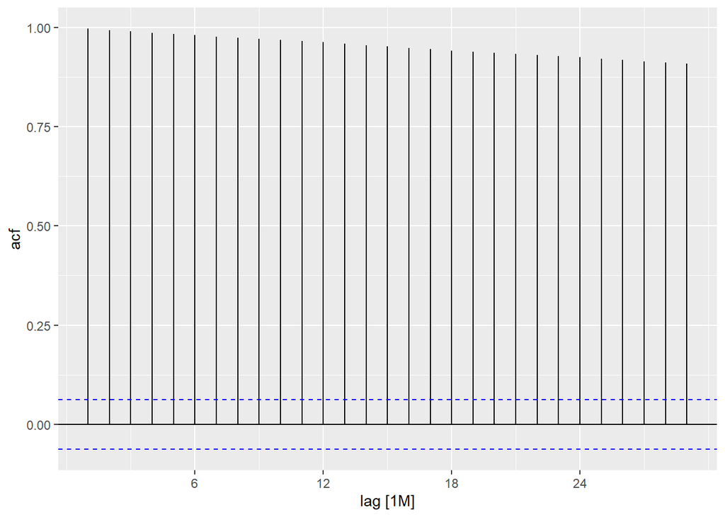

```r
autoplot(ACF(total_private, Employed))
```

In all of these plots, **the trend is so dominant that it is hard to see anything else**. In particular the lagplots and correlogram show very strong and positive correlation between adjacent lags that decay very slowly. The effect of seasonality is much smaller than the effect of the trend and cannot be perceived by visual inspection of the correlogram.

We will need to remove the trend to explore other features of the data. The next chapter (Time Series decomposition) will let us identify the different components of the time series.

# White noise

Time series that show no autocorrelation are called white noise.

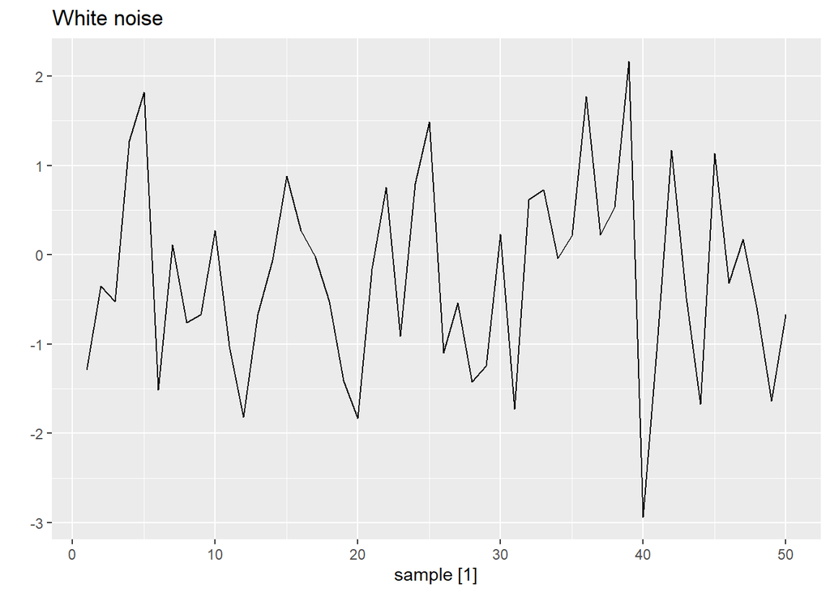

```r
# Sets a seed to ensure repeatibility of random functions
set.seed(30)

y <- tsibble(sample = 1:50, wn = rnorm(50), index = sample)

y %>% autoplot(wn) + labs(title = "White noise", y = "")
```

In particular, the above series samples from a gaussian distribution. **This is the exact same example we saw in lesson 1**. In this case the noise is called **gaussian white noise**.

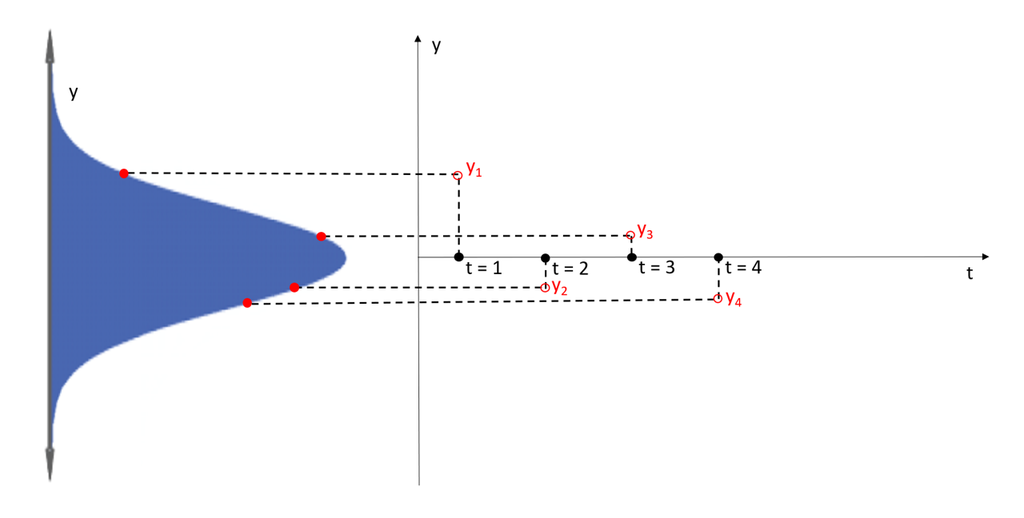

Figure 1: Gaussian white noise

Lets have a look at the correlogram:

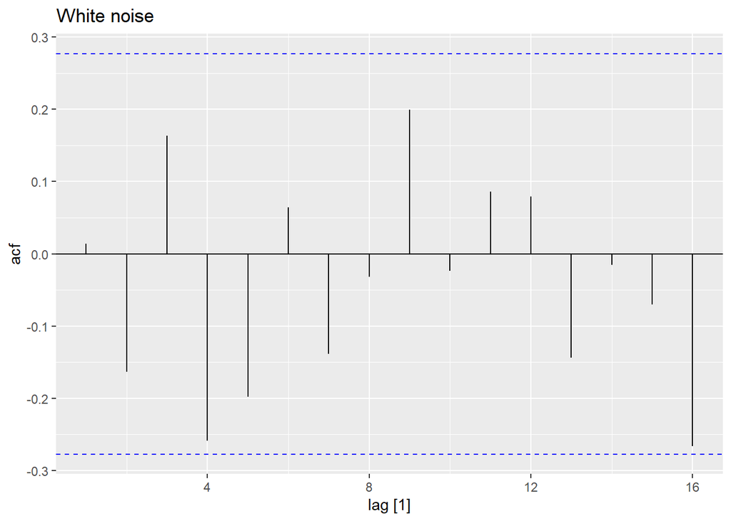

```r
y %>%
  ACF(wn) %>%
  autoplot() + labs(title = "White noise")
```

If one or more large spikes are outside these bounds or if substantially more than 5% of the spikes are outside these bounds, then the time series is probably not white noise.

# Autocorrelation coefficient vs. Pearsons correlation coefficient

This section is not extremely important conceptually, but it will help you better understand the difference between the autocorrelation coefficients and the Pearson’s correlation coefficient.

Every time we compute a lag, we generate new NA values simply because we shift the data backwards and there is nothing to replace the empty values. As a result, the Pearson’s correlation coefficient of each of the scatterplots in the lag plot is not exactly the same as the corresponding autocorrelation coefficient.

The reason is that:

1. The denominator of the ACF (see formula) is the same for all the autocorrelation coefficients and based on the length of the complete time series. The denominator needs to be the same so that comparisons between the autocorrelation coefficients are possible (all values referred to the same magnitude)
2. The numerator has less and less terms for each lag, due to the growing number of `NAs`. This is reflected in the limits of the sum operator in the numerator: $\sum_{t=k+1}^{T}$

On the other hand, if we compute the Pearson’s coefficient for each of the scatterplots, the denominator is different for each scatterplot due to the decreasing number of points in each scatterplot.

As an exercise, let us compute manually the autocorrelation coefficients. We will calculate:

1. The autocorrelation coefficient using its formula insted of the ACF() function.
2. The pearson coefficient (using the standard R function `cor()`.

```r
# Compute the average beer production
avg_beer = mean(recent_production$Beer)

# Compute deviations from mean
recent_production[["beer_dev"]] = recent_production$Beer - avg_beer

# Square deviation from mean
recent_production[["beer_dev_sq"]] = recent_production[["beer_dev"]]^2

# Compute sum of squares
squares = sum(recent_production$beer_dev_sq)

# Prepare an empty vector for the Pearsons correlation coeff output:
pearsons_coeffs = vector("double", 9)

# Prepare an empty vector for the ACF output
ACF_coeffs_manual = vector("double", 9)

for (i in seq(1, 9)) {

  # Prepare column name to access variables
  col_name <- paste0("Beer_lag",as.character(i))

  # Compute Pearsons Correlation coefficient beteen t and i-th lag:
  pearsons_coeffs [i] = cor(recent_production$Beer, recent_production[[col_name]],
                           use="complete.obs", method="pearson")

  # Round results
  pearsons_coeffs = round(pearsons_coeffs, 3)

  # Compute deviations from mean for each lag:
  recent_production[[paste0(col_name,"_dev")]] <- (recent_production[[col_name]] - avg_beer)

  # Compute the autocorrelation coefficient for lag i:
  ACF_coeffs_manual[[i]] <- sum(recent_production[[paste0(col_name,"_dev")]] * recent_production$beer_dev, na.rm = TRUE) / squares

  # Round results
  ACF_coeffs_manual = round(ACF_coeffs_manual, 3)
}

ACF_coeffs_manual
```

```
## [1] -0.053 -0.758 -0.026  0.802 -0.077 -0.657  0.001  0.707 -0.089
```

```r
pearsons_coeffs
```

```
## [1] -0.055 -0.786 -0.028  0.904 -0.087 -0.770  0.001  0.904 -0.113
```

The above are vectors containing the autocorrelation coefficients and the Pearson’s correlation coefficients. The first component measures the strength of linear relationship between the variable and its first lag… and so on.

Now let us compare each of these results to the coefficients we have previously obtained using the ACF() function of the `feasts` package:

```r
# Compare differnces
ACFs$acf[1:9] - ACF_coeffs_manual
```

```
## [1] 0 0 0 0 0 0 0 0 0
```

```r
ACFs$acf[1:9] - pearsons_coeffs
```

```
## [1]  0.002  0.028  0.002 -0.102  0.010  0.113  0.000 -0.197  0.024
```

We observe that:

1. The `ACF()` function of the feasts package is correctly implemented (our results match).
2. The Pearson’s correlation coefficients differ from the autocorrelation coefficients due to the reasons outlined above.